# Authoritarian Institutions and Credibility

Shane Xinyang Xuan

6/13/2017

## Introduction

Do authoritarian institutions constrain? Domestic politics of authoritarian regimes have been of comparativists’ interests since Geddes’ seminal publication (1999). However, the authoritarian politics literature is still lacking in a consensus on the role of (both formal and informal) institutions in different types of authoritarian regimes. This blog post considers one of the controversies in the recent authoritarian literature – whether legislature solves the credibility problem in autocracies, when leaders are supposedly able to renege on their promises, and institutions might not necessarily “tie hands.”

Gelbach and Keefer (2012) proposes that party institutionalization solves authoritarian elites’ credibility problem (and hences positively influences growth and investment). That is, institutions facilitate the ruling coalition’s collective action potential, and make economic elites threat to remove the leader in the presence of asset expropriation credible.

However, the definition of institutionalization, espeically in the context of authoritarian regimes, should be defined in a sticter sense. As Hicken and Kuhonta (2014) has noted, party institutionalization in authoritarian and semi-authoritarian regimes in fact signals a stonger autocratic control of the civil society, instead of better democratic quality. In Manion’s (2015) superb analysis of Chinese local congressional representation, Manion argues that “institutionalization in autocracies must be a story about rulers building a reputation for themselves as rule abiding through the steady accretion of observable (and observed) choices not to renege” (p.154).

In this blog post, I replicate Wilson & Wright’s (2017) paper that studies the relationship between autocratic legislatures and expropriation risk. Wilson & Wright’s (2017) study relies on Geddes’ (1993) typology of authoritarian regimes, which decomposes authoritarian regimes into personalist, single-party, and military regimes. As an extension, I adopt Magaloni et al’s (2013) suggestion of viewing “personalism” as a *feature*, instead of a *subtype* of authoritarian regimes. In particular, Magaloni et al (2013) argues that *personalism*, instead of being characterized as a distinct, dichotomous type, should be measured on a continuum. Using Magaloni et al’s (2013) yields a mixed finding.

The key variables of interest are whether there was an incident of oil expropriation in the given regime in the given year (**oilexp**), whether there is a legislature in the given regime in the given year (**legis**), whether the regime is characterized as personalist in Geddes’ data set (**p**), and how personalist the regime is in Magaloni et al’s data set (**lindex**).

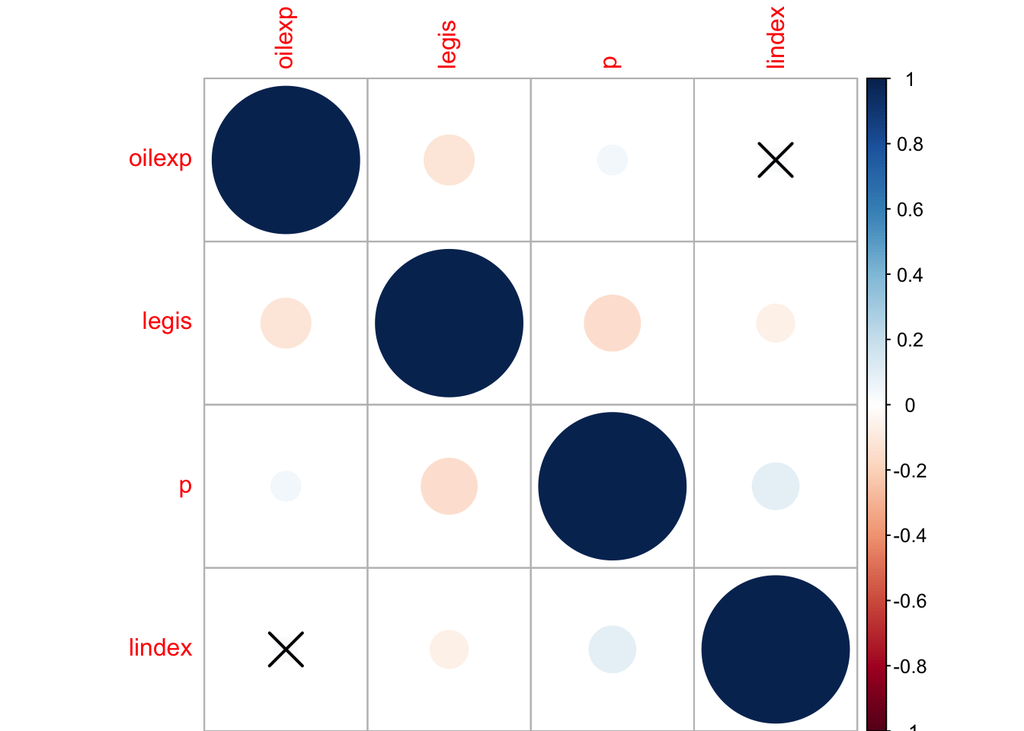

## Different Patterns

In the figure below, red dots are the country-years that are characterized as personalist in Geddes (1999), and black dots are the coutry-years that are characterized as non-personalist. The points are jittered in order to facilitate interpretation. Clearly, there are different patterns of expropriation based on the institutional setup of the country – Autocratic leaders of countries with legislatures are less likely to expropriate economic elites’ assets, and oil expropriations happen more often in personalist regimes compared to non-personalist regimes.

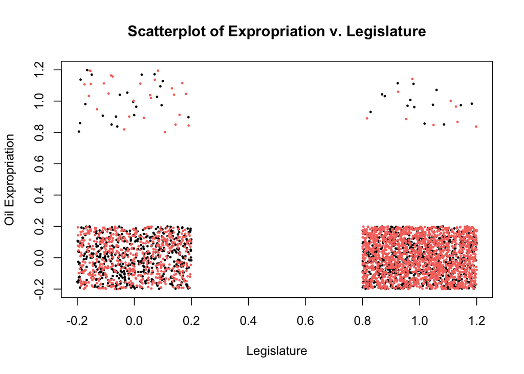

The figure below is the density plots of oil expropriation, and it corroborates the intuition we gained from the previous figure – Personalist regimes have a smaller proportion of non-expropriation cases (that is, personlist regimes are *more* likely to expropriate compared to non-personalist autocracies).

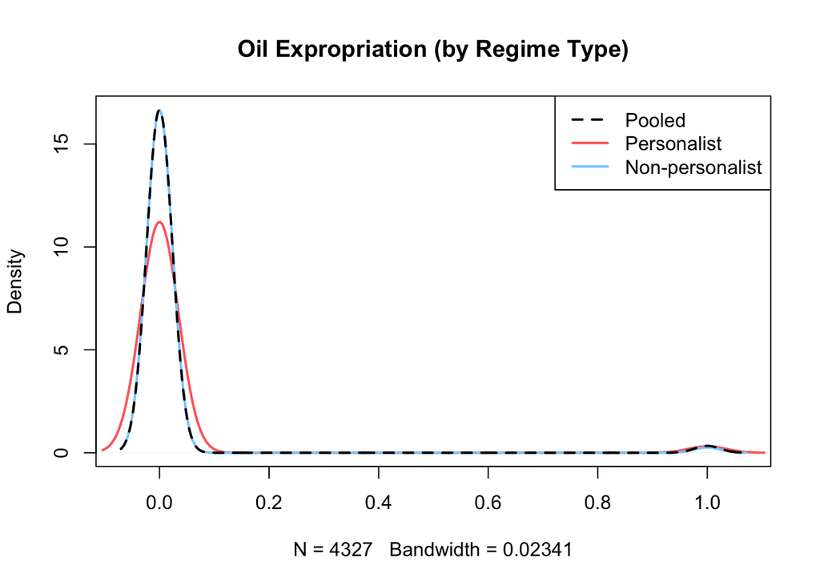

We conduct several statistical analyses in the following section to further investigate the relationship between autocratic institutions and expropriation risk, conditional on the regime type.

## Statistical Analysis

Now, we conduct the main analysis. First, we replicate the findings in Wilson & Wright (2017). Note that we include the following controls: GDP per capita (**gdp**), population size (**pop**), regime duration (**gtime**), and oil rents per capita (**oil**), and they are logged and lagged by one year.

The explanatory variable is whether there is a legislature in the given country-year observation (**legis**), and it is constructed from Cheibub et al. (2010). All the models include country and year fixed effects, and errors are clustered on the country level to control for within-cluster error correlation.

Now we present the results.

```
##                       Model 1 Model 2  Model 3
## Legislature          -0.01859 0.02838 -0.06128
## (Std. Error)           0.0112 0.01301  0.02038
## Pooled                      Y       N        N
## Personalist                 N       Y        N
## Non-personalist             N       N        Y
## Year FE + Country FE        Y       Y        Y
```

We can also present the results using coefficient plots. Note that we indeed find a heterogeneous effect of authoritarian legislatures on leaders’ expropriation risk – Legislature decreases the expropriation risk in non-personalist regimes, but increases the expropriation risk in personalist regimes. The legislature variable is statistically significant in both cases.

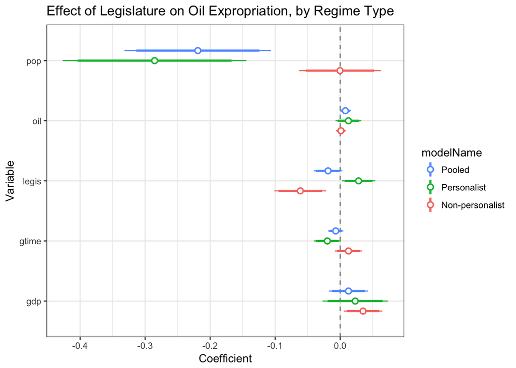

## Using a New Measure of Personalism

In this section, I extend the replication by using Magaloni et al’s (2013) continuous measure of personalism. Magaloni et al (2013) suggests that instead of viewing personalism as a dichotomy, it is meaningful to measure personalism on a continuous measure. *Autocracies of the World Dataset* is one attempt that looks at the authoritarian regimes in a more meticulous manner. For example, the variable **regime_r** measures regime type of a given country-year, **personal1** is a three-point measure of the country-year’s degree of personalism, and **lindex** measures personalism with each regime, calculated by
$$\sum_{i=1}^m\left(\frac{exec_i}{n}\right)^2,$$
where $n$ is the age of the regime, and $exec$ is the number of years that a unique executive $i$ has led the regime. For example, a regime led by only one person up through the observed year yields a personalism index of 1. If leadership changes every year, then the value that **lindex** would take is $\frac{1}{n}$. As an extention of the replication process, I adopt Magaloni et al’s (2013) measure of personalism, and investigate the effect of legislature on authoritarian expropriating behavior. Now, I conduct the main analysis.

The figure below presents the results from two models (country and year fixed effects are *not* reported), and the only difference between them is that the interaction term (**personalism x legis**) uses Geddes’ (1999) dichotomous measure of personalism in the first model , and Magaloni et al’s (2013) continuous measure of personalism in the second model . As we can see, statistical significance of the interaction term (**personalism x legis**), as well as of the constant term for legislature (**legis**) disappears when we use Magaloni et al’s (2013) data.

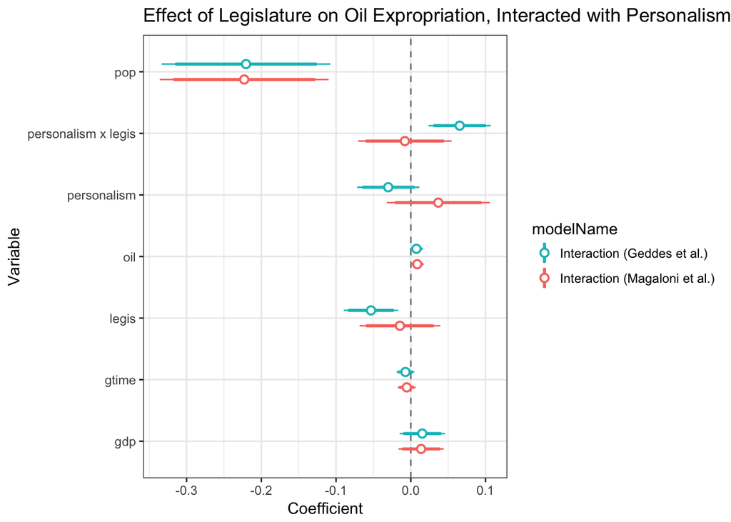

# Counterfactuals

In this section, we create a set of counterfactuals to visually demonstrate the effect of legislature on autocrats’ expropriating behavior, conditional on regime type. The model that we are using to generate the counterfactuals is the second model presented in previous figure, from using Magaloni et al’s (2013) measure of personalism, and interacting it with the legislature variable. Again, country and year fixed effects are not reported in the table below, and standard errors are clustered at the country level.

```
##                         Estimate  Std. Error    t value     Pr(>|t|)
## (Intercept)          3.335484925 0.948394386  3.5169809 0.0004438380
## gdp                  0.013771107 0.015455573  0.8910124 0.3730036042
## pop                 -0.222856964 0.057676496 -3.8639130 0.0001142681
## gtime               -0.005504698 0.006111847 -0.9006602 0.3678510644
## oil                  0.008588054 0.004463528  1.9240509 0.0544554736
## legis               -0.014546372 0.027543823 -0.5281174 0.5974621998
## personalism          0.036788619 0.035152804  1.0465344 0.2954100695
## personalism x legis -0.007967988 0.031917132 -0.2496461 0.8028804216
```

In particular, we generate two scenarios – one for Iraq in 1970, and another for Bangladesh in 1970, in order to demonstrate how personalism and legislature jointly affect the risk of expropriation in authoritarian regimes. Note that the blue band represents the scenario in which Iraq/Bangladesh has a legislature in 1970, and the red band represents the scenario in which Iraq/Bangladesh does not have a legislature in 1970.

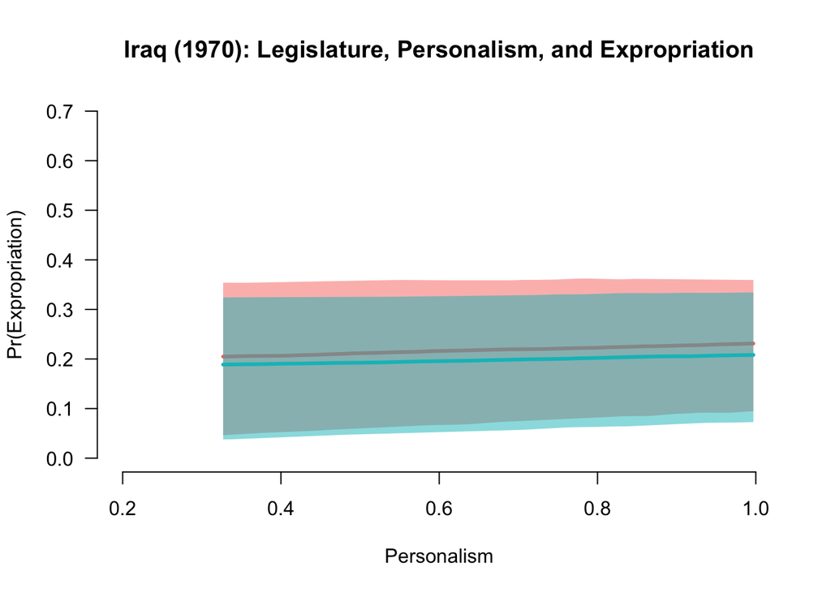

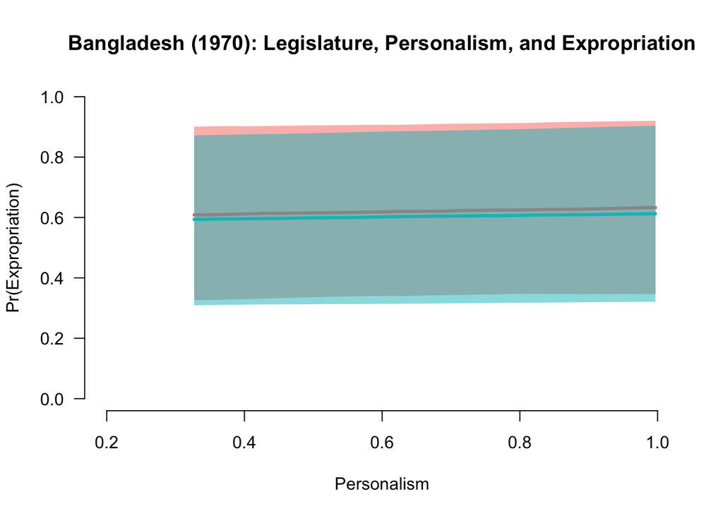

## So What’s Happening Here?

The figure shows the difference between Magaloni et al’s (2013) and Geddes’ (1999) measures of personalism. The horizontal axis is the degree of personalism of the country-year observation using Magaloni et al’s (2013) measure, and the dots are red if the observation is coded as personalist in Geddes’ (1999) data set, and black if the observation is coded as non-personalist in Geddes (1999). Clearly, there are multiple cases in which a regime-year is considered relatively non-personalist by Magaloni, but personalist by Geddes.

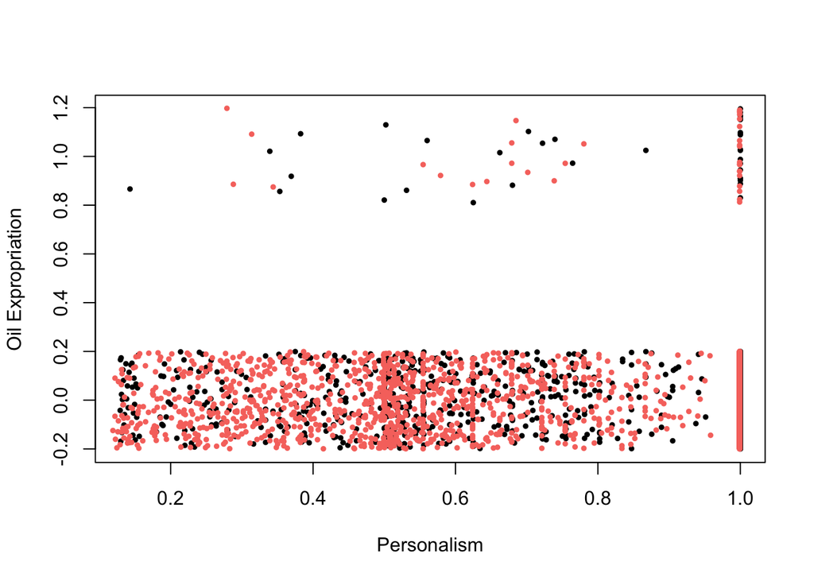

We now take a closer look at the regimes that are considered relatively non-personalist by Magaloni et al (2013), but personalist by Geddes (1999).

```r
unique(data2$country.y[which(data2$lindex<0.3 & data2$p==1)])
```

```
## [1] "Armenia"      "Liberia"      "Saudi Arabia" "Yemen North"
## [5] "Nepal"
```

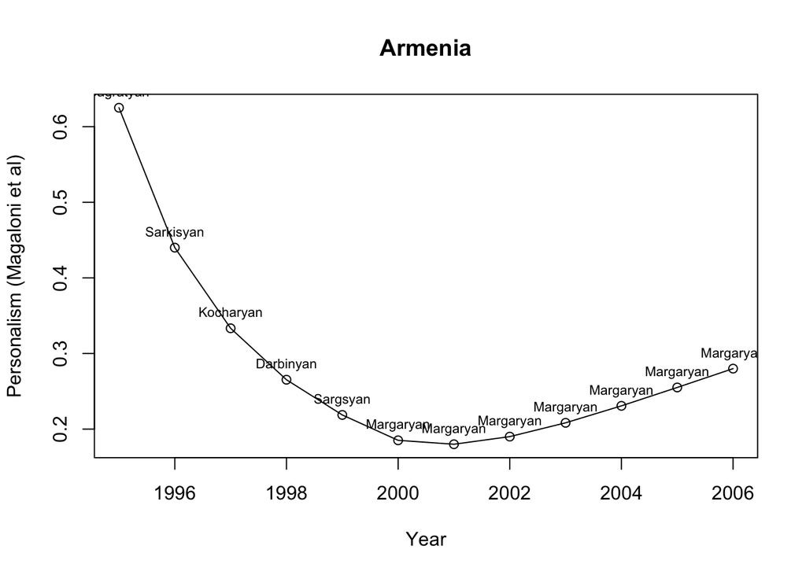

What about Saudi Arabia?

[figure not shown]

From the inspection above, it seems that there are *some* irregularities in Magaloni et al’s (2013) data set that are warrent further attention.

## Conclusion

The presence of legislature, conditioned on personalism, does not change authoritarian regime’s expropriating behavior when we use Magaloni et al’s (2013) data. The current authoritarian politics literature rests heavily on the measure and classification of authoritarian regimes proposed by Geddes’ (1999) seminal article. However, the particular challenge of using Geddes, Wright, and Frantz’s (2012) and Cheibub, Gandhi, and Vreeland’s (2010) datasets are that the classification of authoritarian regimes is highly dependent on researchers’ prior assumption that subtypes of authoritarian regimes are personalist, military, single-party, and dominant-party regimes. However, as Magaloni et al (2013) has pointed out, personalism is, to some extent, a continuous measure. Hence, the classic topology of authoritarian regimes following Geddes’s paradigm (2003) might be subject to empirical critique, or even result in misleading conclusion.

Upon an initial look at Magaloni et al’s (2013) data, it seems that there exists some empirical irregularity in the data that is worth further study. So there is in need of a more careful conceptualization of personalism, as well as a more reliable measure of personalism in authoritarian regimes.